# Introduction to Bayesian Statistics with R

5 May 2025

## Two sample \(t\)-test in R

base R

With the t.test(…) function

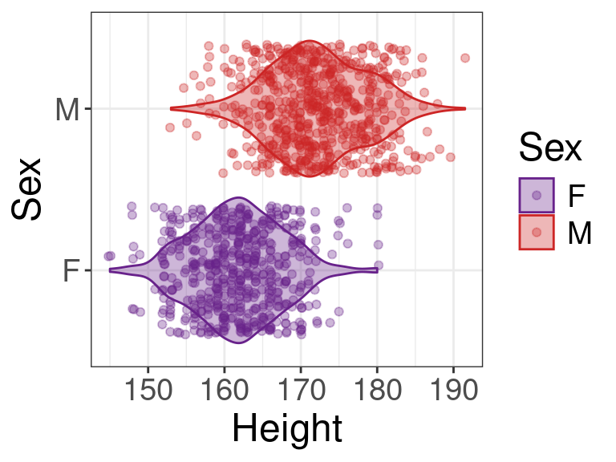

```
##
##  Welch Two Sample t-test
##
## data:  Height by Sex
## t = -29.278, df = 1152.2, p-value < 2.2e-16
## alternative hypothesis: true difference in means between group F and group M is not equal to 0
## 95 percent confidence interval:
##  -11.151169  -9.750496
## sample estimates:
## mean in group F mean in group M
##        161.7041        172.1550
```

```r
# Read in the swiss army data from file
swiss_army_df <- read.csv("./data/Zurich_data.csv", as.is = FALSE)
# use the regression formulation and store result
(t_test <- t.test(Height ~ Sex, swiss_army_df))
```

How are we modelling the data?

## Two sample \(t\)-test in R

base R

\(\left.\right.\)

Each group is normally distributed with own mean and variance

- Group 1 with \(N_1\) subjects: \(h \sim \mathcal{N}(\mu_1,\sigma_1^2)\)
- Group 2 with \(N_2\) subjects: \(h \sim \mathcal{N}(\mu_2,\sigma_2^2)\)

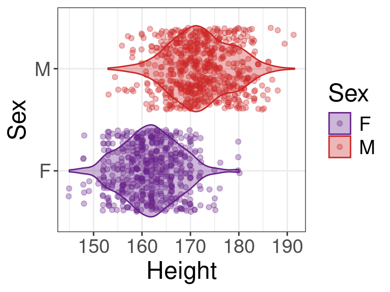

And we compare the \(t\)-statistic

\[t=\frac{m_1-m_2}{\sqrt{\frac{s_1^2}{N_1}+\frac{s_2^2}{N_2}}}\]

- from sample means \(m\) and variances \(s^2\)

To the \(t\)-distribution under the null \(\mu_1 = \mu_2\)

- with complicated formula for the degrees of freedom \(\nu\)

Let’s first assume equal variance for the two groups

## Two sample \(t\)-test in R

base R

With the t.test(…, var.equal = TRUE) function

Each group is normally distributed with own mean and **common** variance

- Group 1: \(h \sim \mathcal{N}(\mu_1,\sigma^2)\)
- Group 2: \(h \sim \mathcal{N}(\mu_2,\sigma^2)\)

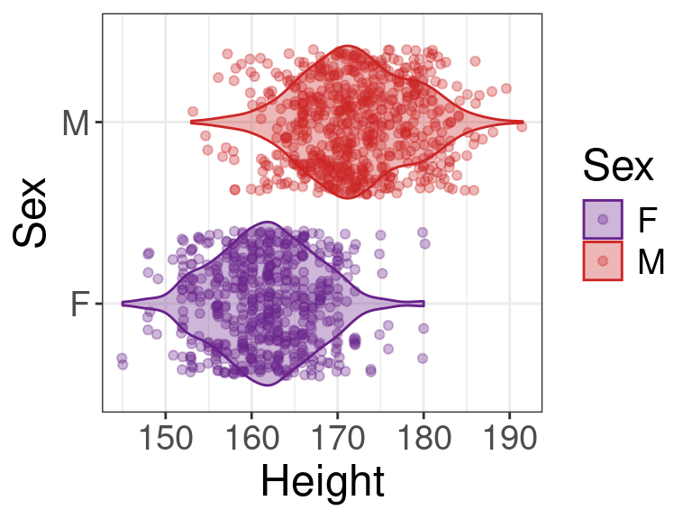

```r
(t_test_v <- t.test(Height ~ Sex,
  swiss_army_df, var.equal = TRUE))
```

```
##
##  Two Sample t-test
##
## data:  Height by Sex
## t = -29.075, df = 1158, p-value < 2.2e-16
## alternative hypothesis: true difference in means between group F and group M is not equal to 0
## 95 percent confidence interval:
##  -11.156056  -9.745608
## sample estimates:
## mean in group F mean in group M
##        161.7041        172.1550
```

How else could we parametrise the model?

## Two sample \(t\)-test in R

base R

\(\left.\right.\)

In terms of the difference in means

- Group 1: \(h \sim \mathcal{N}(\mu,\sigma^2)\)
- Group 2: \(h \sim \mathcal{N}(\mu + \beta,\sigma^2)\)

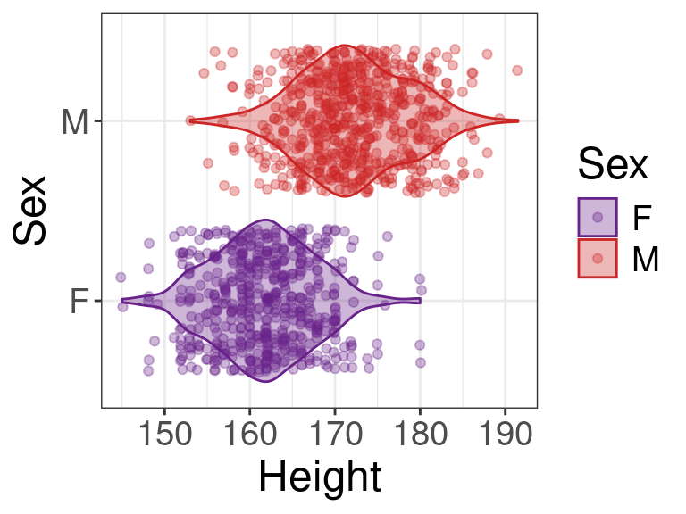

Or more compactly

\[h \sim \mathcal{N}(\mu,\sigma^2)\] with

\[\mu = \beta_0 + \beta_1*\mathrm{Group}\]

How else could we implement this model in R?

## Two sample \(t\)-test in R

base R

With the lm(…) function

```r
lmfit <- lm(Height ~ Sex, swiss_army_df) # run the linear model
summary(lmfit)$coefficients # extract regression coefficients
```

```
##              Estimate Std. Error   t value      Pr(>|t|)
## (Intercept) 161.70412  0.2640480 612.40431  0.000000e+00
## SexM         10.45083  0.3594386  29.07543 5.284626e-140
```

If we compare to the t.test(…, var.equal = TRUE) results

```r
c(t_test_v$estimate[2]-t_test_v$estimate[1], t_test_v$stderr, t_test_v$statistic, t_test_v$p.value)
```

```
## mean in group M                               t
##    1.045083e+01    3.594386e-01   -2.907543e+01   5.284626e-140
```

- can check they are the same

## Stan

Stan

\(\left.\right.\)

Stan is open-source software

- full Bayesian statistical inference
- efficient state-of-the-art MCMC sampling
- and more

R interface Rstan

We’ll use *yet* another interface brms

- Bayesian regression modelling using Stan
- syntax more like lm

```r
if (!require(brms)) { # install if not yet installed
  install.packages("brms")
}
library(brms) # load the library
```

## Two sample \(t\)-test in Stan

Stan

With the brm(…) function

```r
brmfit <- brm(Height ~ Sex, swiss_army_df) # run the model
summary(brmfit) # extract information from the inference
```

```
##  Family: gaussian
##   Links: mu = identity; sigma = identity
## Formula: Height ~ Sex
##    Data: swiss_army_df (Number of observations: 1160)
##   Draws: 4 chains, each with iter = 2000; warmup = 1000; thin = 1;
##          total post-warmup draws = 4000
##
## Regression Coefficients:
##           Estimate Est.Error l-95% CI u-95% CI Rhat Bulk_ESS Tail_ESS
## Intercept   161.70      0.26   161.21   162.21 1.00     4197     3402
## SexM         10.46      0.36     9.75    11.17 1.00     4114     3033
##
## Further Distributional Parameters:
##       Estimate Est.Error l-95% CI u-95% CI Rhat Bulk_ESS Tail_ESS
## sigma     6.11      0.13     5.86     6.37 1.00     4129     3058
##
## Draws were sampled using sampling(NUTS). For each parameter, Bulk_ESS
## and Tail_ESS are effective sample size measures, and Rhat is the potential
## scale reduction factor on split chains (at convergence, Rhat = 1).
```

## Two sample \(t\)-test posterior samples

Stan

Can access the posterior samples with the as_draws(…) functions

```r
head(as_draws_df(brmfit)) # posterior samples in a data frame
```

```
## # A draws_df: 6 iterations, 1 chains, and 5 variables
##   b_Intercept b_SexM sigma lprior  lp__
## 1         162     10   5.9   -5.8 -3748
## 2         161     11   6.3   -5.9 -3749
## 3         162     10   5.9   -5.8 -3748
## 4         162     11   6.5   -5.9 -3753
## 5         161     11   6.3   -5.9 -3750
## 6         161     11   6.3   -5.9 -3751
## # ... hidden reserved variables {'.chain', '.iteration', '.draw'}
```

- rounded for display
- the lp__ column is the log-probability of each drawn sample
- can use for downstream analysis

\(\longrightarrow\) but there are many inbuilt functions instead!

## Two sample \(t\)-test coefficients

Stan

Use the fixef(…), ranef(…), coef(…) functions

```r
fixef(brmfit) # extract difference in mean coefficient (fixed effect)
```

```
##           Estimate Est.Error       Q2.5     Q97.5
## Intercept 161.6996 0.2609716 161.213621 162.21077
## SexM       10.4574 0.3565870   9.754368  11.16742
```

- *cf* 95% CI of the equal variance \(t\)-test

```r
t_test_v$conf.int # extract CI from t-test
```

```
## [1] -11.156056  -9.745608
## attr(,"conf.level")
## [1] 0.95
```

Also have the distribution of \(\sigma\)

```r
summary(brmfit)$spec_pars # extract sigma (model specific parameters)
```

```
##       Estimate Est.Error l-95% CI u-95% CI     Rhat Bulk_ESS Tail_ESS
## sigma 6.108085 0.1265629  5.86374  6.36539 1.000153 4128.585 3057.789
```

## Two sample \(t\)-test chains

Stan

Plot chains with the plot(…) function

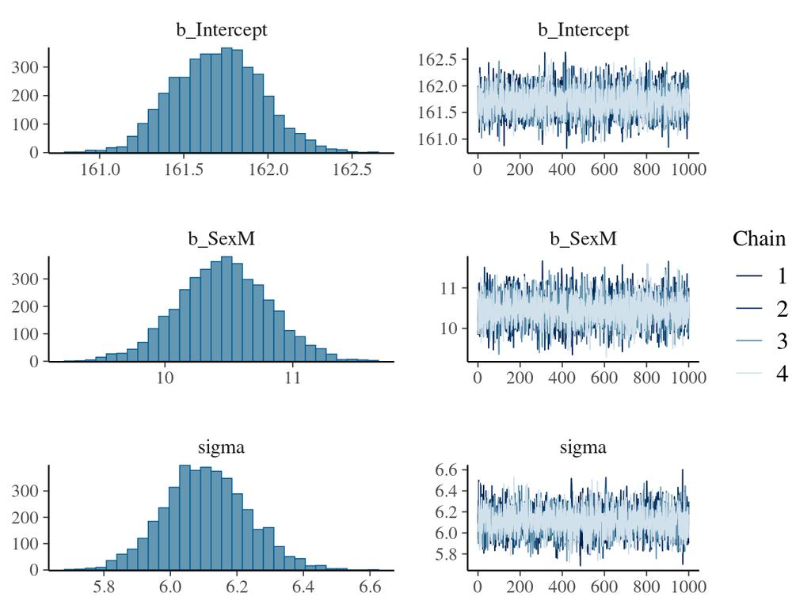

```r
plot(brmfit) # plot the chains
```

## Two sample \(t\)-test plots

Stan

Plot components with the mcmc_plot(…) function

We are interested in regression coefficient \(\beta_1\)

- (b_)SexM in the brms syntax

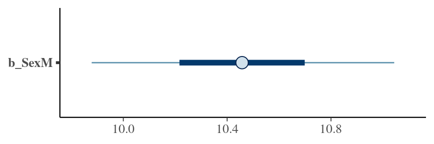

```r
mcmc_plot(brmfit, variable = "b_SexM",
          type = "intervals")
```

Also further options, including

- “dens”, “hist” and “violin”

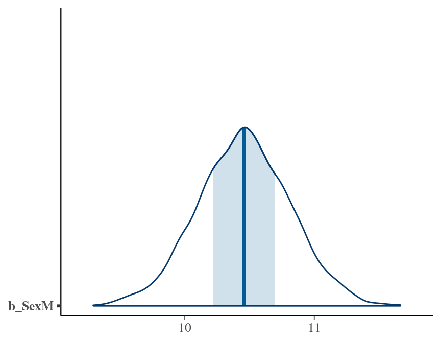

```r
mcmc_plot(brmfit, variable = "b_SexM",
          type = "areas")
```

## Two sample \(t\)-test pairwise plots

Stan

Explore pairwise dependencies with the pairs(…) function

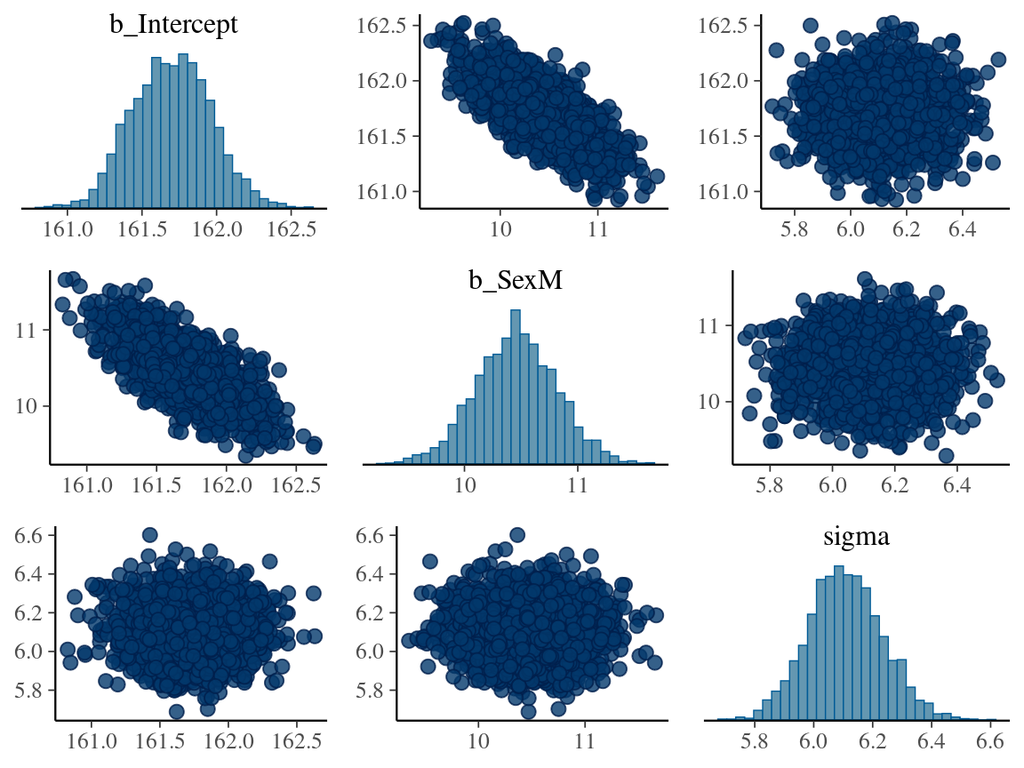

```r
pairs(brmfit) # plot pairwise
```

## Two sample \(t\)-test predictive check

Stan

Predictive check with the pp_check(…) function

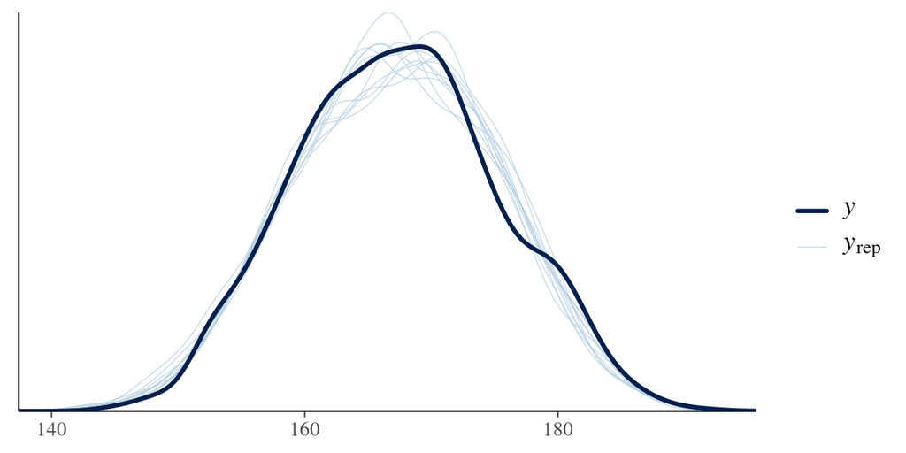

```r
pp_check(brmfit) # plot predictive check
```

Compares kernel density of the data (dark)

- to samples from the model (default 10 sets)

## Two sample \(t\)-test

Stan

\(\left.\right.\)

How might we parametrise a \(t\)-test with unequal variance?

- Group 1: \(h \sim \mathcal{N}(\mu,\sigma^2)\)
- Group 2: \(h \sim \mathcal{N}(\mu + \beta,\sigma^2 + \gamma)\)

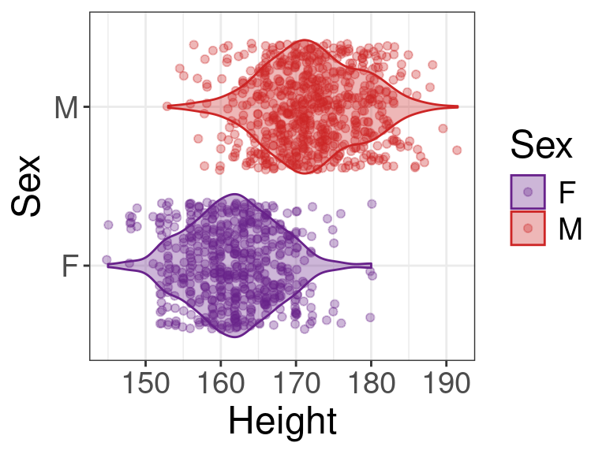

Or more compactly

\[h \sim \mathcal{N}(\mu,\sigma^2)\] with

\[\mu = \beta_0 + \beta_1*\mathrm{Group}\] \[\sigma = \gamma_0 + \gamma_1*\mathrm{Group}\]

Just need the syntax for brms

## Two sample \(t\)-test in Stan

Stan

Wrap model inside bf(…) function

```r
brmfit_t <- brm(bf(Height ~ Sex, sigma ~ Sex), swiss_army_df) # run the model
summary(brmfit_t)
```

```
##  Family: gaussian
##   Links: mu = identity; sigma = log
## Formula: Height ~ Sex
##          sigma ~ Sex
##    Data: swiss_army_df (Number of observations: 1160)
##   Draws: 4 chains, each with iter = 2000; warmup = 1000; thin = 1;
##          total post-warmup draws = 4000
##
## Regression Coefficients:
##                 Estimate Est.Error l-95% CI u-95% CI Rhat Bulk_ESS Tail_ESS
## Intercept         161.71      0.24   161.25   162.18 1.00     4949     3413
## sigma_Intercept     1.76      0.03     1.70     1.82 1.00     4259     2988
## SexM               10.44      0.35     9.76    11.12 1.00     4988     3455
## sigma_SexM          0.09      0.04     0.01     0.17 1.00     3984     3135
##
## Draws were sampled using sampling(NUTS). For each parameter, Bulk_ESS
## and Tail_ESS are effective sample size measures, and Rhat is the potential
## scale reduction factor on split chains (at convergence, Rhat = 1).
```

## Two sample \(t\)-test coefficients

Stan

Use the fixef(…), ranef(…), coef(…) functions

```r
fixef(brmfit_t) # extract coefficients (fixed effect)
```

```
##                     Estimate  Est.Error         Q2.5       Q97.5
## Intercept       161.71089954 0.23901123 1.612478e+02 162.1815086
## sigma_Intercept   1.75945211 0.03114949 1.701122e+00   1.8210367
## SexM             10.44049828 0.34982380 9.760584e+00  11.1211836
## sigma_SexM        0.08902494 0.04246519 6.932626e-03   0.1713223
```

With this model formulation brms

- has a *log* link for \(\sigma\)

Actually sampling/estimating \(\log(\sigma)\)

- SD estimate for women would be exp(1.759) = 5.809
- SD estimate for men would be exp(1.759 + 0.089) = 6.35

To have the same treatment (with the log-link) for the equal variance model we could specify

```r
brmfit_again <- brm(bf(Height ~ Sex, sigma ~ 1), swiss_army_df) # equal variance model
```

## Two sample \(t\)-test model comparison

Stan

Compare the predictive checks from the pp_check(…) function

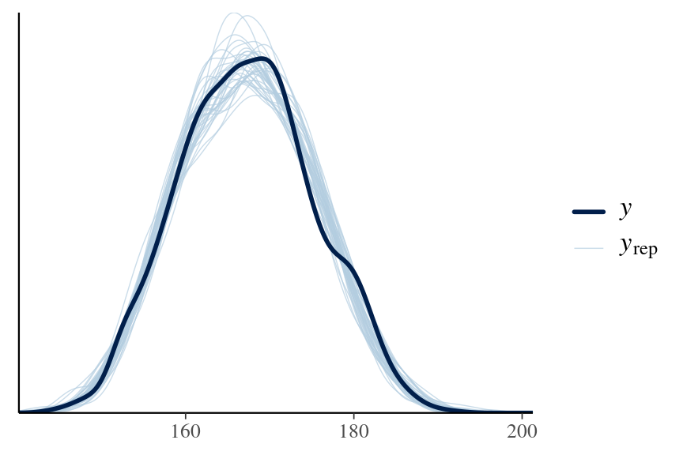

```r
pp_check(brmfit_t, ndraws = 40)
```

*unequal variance*

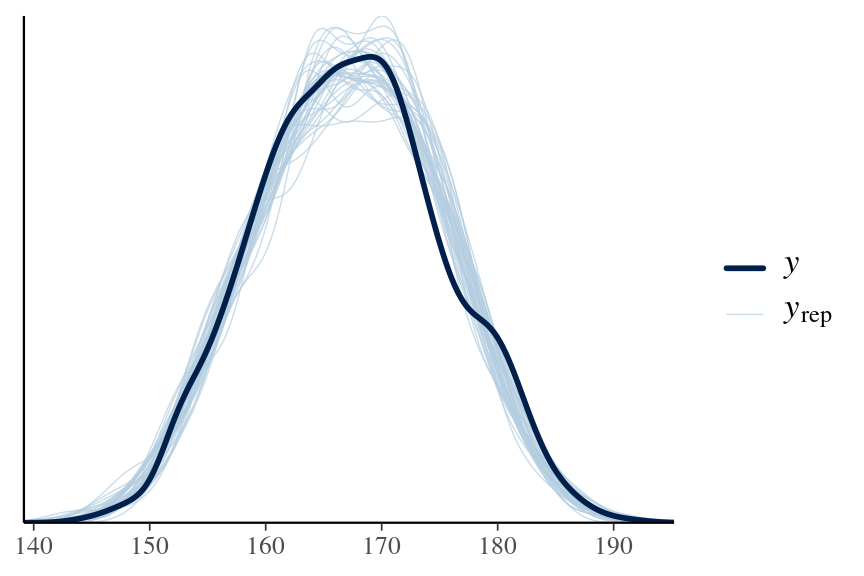

```r
pp_check(brmfit, ndraws = 40)
```

*equal variance*

- Similar in this case

## Summary

With a \(t\)-test parametrised like lm

- we can build up more complicated models
- equal variance, unequal variance, \(\ldots\)

Easily run MCMC-based sampling with bmrs

- modelling syntax with regression formula
- bf(… ~ …)

Can extract and visualise the output

- coefficients and their CIs
- distributions of the coefficients
- posterior checks

But for fully Bayesian inference

- we need to specify our priors \(\rightarrow\) Part 6

\(\rightarrow\) Exercises 5